# Differential Distributions of Starbucks and Dunkin’ Donuts in Eastern MA

Delaney Moran

May 24, 2016

### Abstract:

The present analysis explores the comparative distributions of Dunkin’ Donuts and Starbucks in eastern Massachusetts. It pulls income and demographic data from [Social Explorer](http://old.socialexplorer.com/pub/reportdata/HtmlResults.aspx?reportid=R11178485) and location data from the Google Places API radar searches. The MA shapefile was loaded [here](https://catalog.data.gov/dataset/tiger-line-shapefile-2015-state-massachusetts-current-census-tract-state-based-shapefile).

Mapping both franchises in the six counties around Boston revealed that there are many more Dunkin’ Donuts than Starbucks locations in eastern Massachusetts. Additionally, the two franchises have different geographic distributions and appear to cater to different clientele, both spatially and economically. Starbucks are more densely distributed in cities and located in areas with higher median incomes. Dunkin’ Donuts are more densely distributed in the suburbs, and located in areas with lower median incomes.

### Introduction:

Global coffee consumption as well as the U.S. coffeehouse industry have been steadily on the rise in since 2009 (ICO; IBISWorld). In the United States, the two leading coffeehouse chains are Starbucks Corporation and Dunkin’ Brands Inc., which collectively comprised over 60% of the coffeehouse market in 2014 (CIEEDAC). Despite sharing a competitive market with relatively low profit margins, the two chains have steadily expanded their number of locations over the past ten years (Starbucks, “Number of Starbucks…”; Dunkin’ Donuts, “Number of Dunkin’…”).

The two chains are distinct from each other, however, in several regards. For one, Starbucks is a much larger, international corporation, and the second most valuable fast food brand worldwide behind McDonalds (Brown), bringing in over $19 billion in revenue in 2015 (Starbucks, “Revenue of Starbucks…”), whereas Dunkin’ Donuts, exclusively domestic, made just over $800 million in 2015 (Dunkin’ Donuts, “Revenue of Dunkin’).

Additionally, the two chains have very distinct company philosophies. Dunkin’ Donuts was founded in 1950 in Quincy, MA by William Rosenberg. He started with a canteen truck, selling refreshments to workers at factories and construction sites. He saw that his most lucrative items were coffee and donuts and so decided to open a permenant location selling these items (“William Rosenberg”). The Dunkin’ Donuts mission is to “make and serve the freshest, most delicious coffee and donuts quickly and courteously in modern, well-merchandised stores” (Dunkin Donuts, “Dunkin’ Donuts”). Its website emphasizes speed of service and customer loyalty.

Starbucks, founded in Seattle, WA in 1971, was born out of the desire to create a coffeehouse with the same feel as traditional Italian coffee bars. CEO, Howard Schultz, wanted to create “a place for conversation and a sense of community, a third place between work and home” (Starbucks, “Company Information”). The Starbucks website emphasizes both the premium quality of its products, but also heavily underscores this community aspect, which Dunkin’ Donuts does not mention at all. The company mission is “to inspire and nurture the human spirit – one person, one cup, and one neighborhood at a time” and they strive to “make sure everything [they] do is through the lens of humanity – from our commitment to the highest quality coffee in the world, to the way we engage with our customers and communities to do business responsibly” (Starbucks, “Company Information”).

This community experience comes at a price, however. A preliminary price analysis of both franchises shows that for comparable items, Starbucks is reliably more expensive. One notable exception is for their breakfast sandwiches, where Dunkin’ Donuts’ is more expensive, though the difference is very small. All price estimates came from fastfoodmenuprices.com and are estimates only.

| Food | oz | DDprice | SBprice | Percent_Difference |
| --- | --- | --- | --- | --- |
| Breakfast Sandwich | NA | 3.59 | 3.45 | -3.90 |
| Donut/Pastry | NA | 0.99 | 2.45 | 147.47 |
| Croissant | NA | 1.49 | 2.45 | 64.43 |
| Coffee | 16 | 1.89 | 2.10 | 11.11 |
| Coffee | 20 | 2.09 | 2.45 | 17.22 |
| Iced Coffee | 24 | 2.49 | 2.95 | 18.47 |
| Latte | 16 | 3.19 | 3.65 | 14.42 |
| Latte | 20 | 3.69 | 4.15 | 12.47 |
| Coolatta/Frappuccino | 24 | 3.99 | 4.45 | 11.53 |

These observations about company differences led to two main hypotheses:

- Because of its in-state roots, there are more Dunkin’ Donuts in this region than Starbucks.
- The two franchises market to different clientele, both spatially and economically.

### Methods:

#### Area of Interest

This investigation explores the distribution of both franchises in the six counties comprising and surrounding Boston: Suffolk, Essex, Middlesex, Norfolk, Bristol, and Plymouth.

Income and demographic data for this region was obtained from [Social Explorer](http://old.socialexplorer.com/pub/reportdata/HtmlResults.aspx?reportid=R11178485), and the MA shapefile was loaded [here](https://catalog.data.gov/dataset/tiger-line-shapefile-2015-state-massachusetts-current-census-tract-state-based-shapefile).

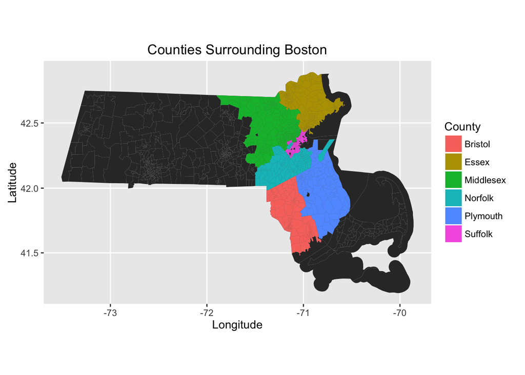

| County | Avg_Median_Income |
| --- | --- |
| Bristol | 57775.35 |
| Essex | 71855.18 |
| Middlesex | 89482.64 |
| Norfolk | 93377.22 |
| Plymouth | 77808.76 |
| Suffolk | 58401.68 |

#### Franchise Locations

The franchise location data was scraped from the Google Places API. The Google Places API allows for radar searches that take a latitude, longitude, and radius, and return all the results of a search query (in this case, Starbucks and Dunkin’ Donuts) within that radius. I adapted code from a previous student ([wjones127](https://github.com/wjones127/franchise-densities)) and covered the area of interest in radar searches. See the plot below.

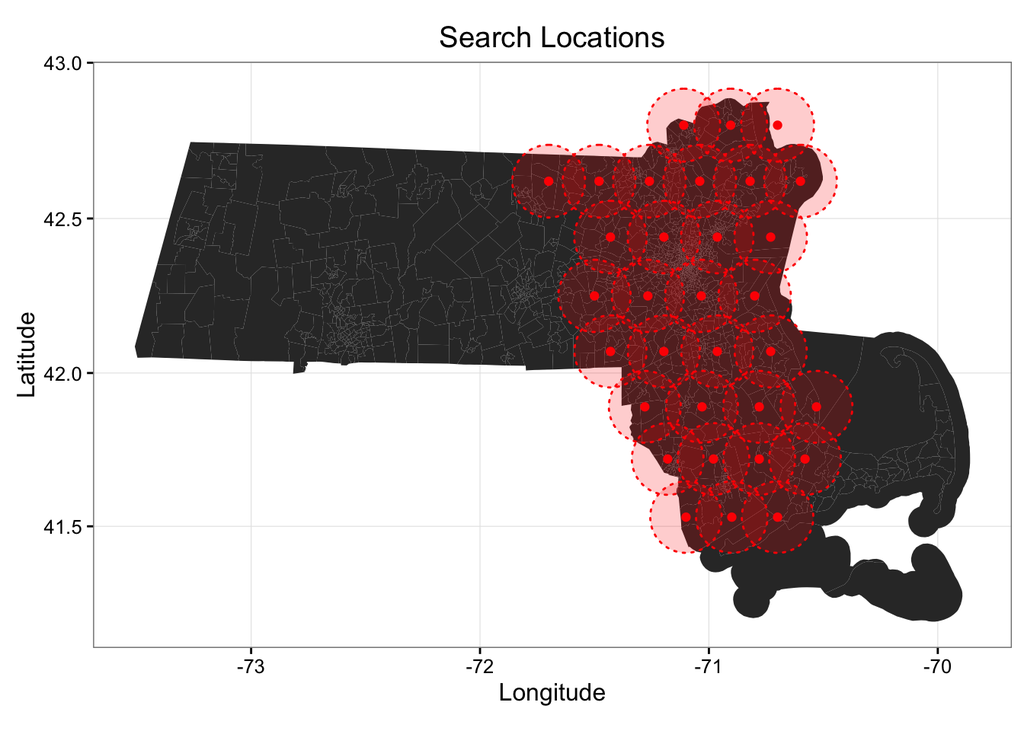

Below is a map displaying the results of the radar searches. Dunkin’ Donuts locations are demarcated with an orange dot and Starbucks locations with a green dot.

```
## Deleting rows:  5 6 8 13 199 200
```

```
## Deleting rows:  3 6 10 15 20 23 24 34 36 65 562 564 565 570 572 574 575 663 666 669 670 673 674 677 678 681 682 683 684 686 687 689 693 694 695 697 698 699 701 702 765 766 768 769 770 781 782 783 785
```

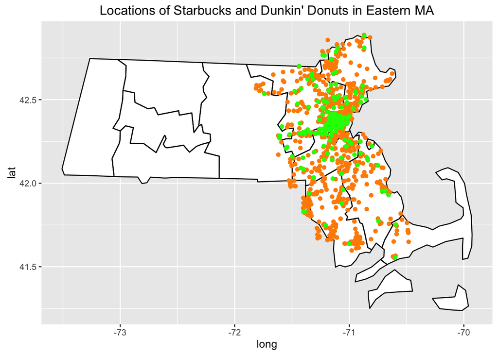

| Franchise | Count |
| --- | --- |
| Starbucks | 195 |
| DunkinDonuts | 752 |

As is evident in both the map and the above tables, there are almost fourfold the number of Dunkin’ Donuts as Starbucks locations in eastern MA.

### Spatial Distribution Analysis

In order to test the hypothesis that the two franchises cater to different populations, and thus have different distribution patterns, it is useful to graph the densities of one against the other.

[interactive chart not shown]

Each dot represents a census tract, with the x value carrying information about Dunkin Donuts density in that tract and the y value carrying information about Starbucks density. A positive trend would indicate that both franchises pick locations in the same areas, while a negative trend would indicate that their distributions do not overlap. Here, there is a net positive trend, which makes sense; in areas with more development, we would expect more of both franchises. Additionally, certain trendlines appear of common ratios of the two franchises.

To examine the differences between the two distributions, we need to look at the data more closely. The first variable I looked at was city vs. subarbs, where Suffolk County was classified as Boston, proper, and all of the other counties were considered suburbs. When the data is split like this, an interesting trend emerges. The following graph shows the franchise densities of Starbucks and Dunkin’ Donuts in the city vs. the subarbs.

[interactive chart not shown]

It is evident that the absolute number of Dunkin’ Donuts in both the city and the subarbs is higher than that of Starbucks. However. Interestingly, there are more Dunkin’ Donuts per 1000 people in the suburbs than the city, while there are fewer Starbucks per 1000 people in the subarbs than the city. The following ANOVA output shows that there is, in fact, a statistically significant interaction effect between Franchise and region (city vs. suburbs). F = 4.462, p = 0.0348.

```
##                                                      Df Sum Sq Mean Sq
## city_descript1$Franchise                              1   7.29   7.293
## city_descript1$cityproper                             1   0.01   0.007
## city_descript1$Franchise:city_descript1$cityproper    1   0.15   0.145
## Residuals                                          2042  66.48   0.033
##                                                    F value Pr(>F)
## city_descript1$Franchise                           224.019 <2e-16 ***
## city_descript1$cityproper                            0.211 0.6458
## city_descript1$Franchise:city_descript1$cityproper   4.462 0.0348 *
## Residuals
## ---
## Signif. codes:  0 '***' 0.001 '**' 0.01 '*' 0.05 '.' 0.1 ' ' 1
```

The following plot encapsulates this phenomenon. Deviations from the line y = 0 represent relative differences in the franchise densities in the suburbs relative to Boston.

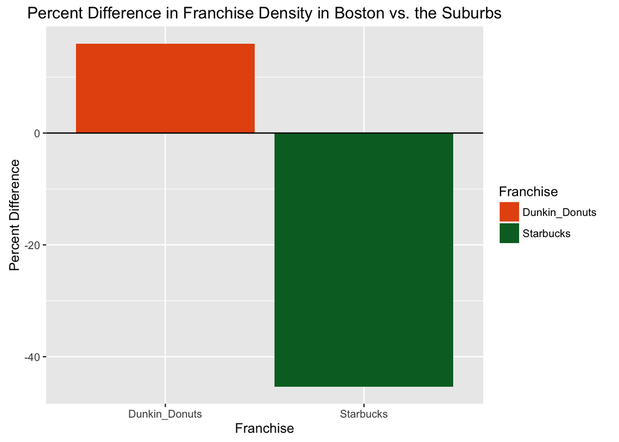

| Franchise | Region | Density | stdev |
| --- | --- | --- | --- |
| Dunkin_Donuts | Suburbs | 0.1648403 | 0.206 |
| Dunkin_Donuts | Boston | 0.1384579 | 0.274 |
| Starbucks | Suburbs | 0.0373854 | 0.102 |
| Starbucks | Boston | 0.0543383 | 0.210 |

| Franchise | Percent_Change |
| --- | --- |
| Dunkin_Donuts | 16.00487 |
| Starbucks | -45.34632 |

I wanted to make this using plotly (instead of the ancillary tables), but there is a documented bug where plotly renders negative ggplot bar graphs positive, which takes away the main message of the graph.

##### Distributions by County

The distribution of Starbucks and Dunkin’ Donuts can be further explored by breaking up the “Suburbs” category. The below plot shows the densities of Dunkin’ Donuts and Starbucks by county. Again, we see that the densities of one franchise does not predict the other. In fact, there almost appears to be an inverse trend. Additionally, average median income for each county is displayed as a point (scaled down by a factor 10^-6).

[interactive chart not shown]

A two-way between-groups ANOVA showed that the interaction between franchise and county is statiscally significant. F = 5.574, p 0.0000416. See the output below.

```
##                                            Df Sum Sq Mean Sq F value
## county_data$Franchise                       1   7.29   7.293 225.920
## county_data$County                          5   0.07   0.014   0.433
## county_data$Franchise:county_data$County    5   0.90   0.180   5.574
## Residuals                                2034  65.66   0.032
##                                            Pr(>F)
## county_data$Franchise                     < 2e-16 ***
## county_data$County                          0.826
## county_data$Franchise:county_data$County 4.16e-05 ***
## Residuals
## ---
## Signif. codes:  0 '***' 0.001 '**' 0.01 '*' 0.05 '.' 0.1 ' ' 1
```

### Economic Distribution Analysis

The next research question was whether the franchise distributions are related to income.

In order to test this, I performed linear regressions using median income as the predictor variable of Dunkin’ Donuts and Starbucks densities on the census tract level. The tables below show the resulting coefficients of the regressions, as well as visualizations.

##### Starbucks

|  | Estimate | Std. Error | t value | Pr(>\|t\|) |
| --- | --- | --- | --- | --- |
| (Intercept) | 0.0118633 | 0.0099623 | 1.190813 | 0.2340037 |
| med_inc | 0.0000004 | 0.0000001 | 3.146631 | 0.0016995 |

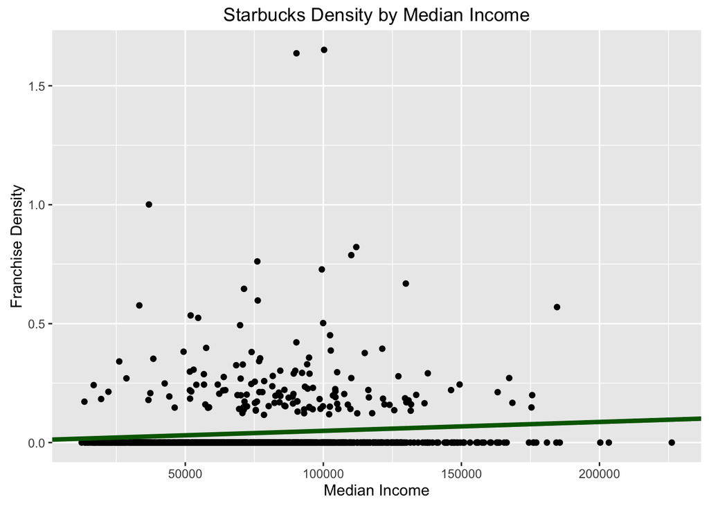

##### Dunkin’ Donuts

|  | Estimate | Std. Error | t value | Pr(>\|t\|) |
| --- | --- | --- | --- | --- |
| (Intercept) | 0.1885499 | 0.0169997 | 11.091384 | 0.0000000 |
| med_inc | -0.0000004 | 0.0000002 | -1.840086 | 0.0660457 |

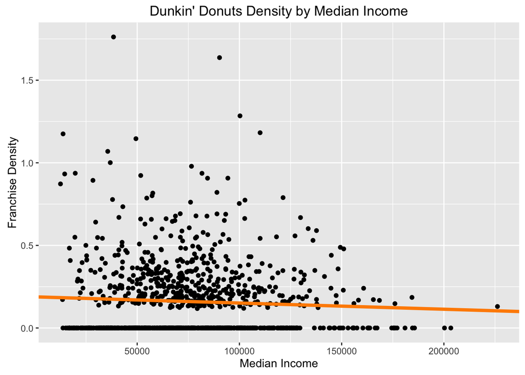

A linear regression revealed that median income did significantly predict Starbucks densities, such that census tracts with higher median incomes had more Starbucks. This was subtle (a very small slope), but nonetheless significant (p = 0.0017). For Dunkin’ Donuts, the relationship was only marginally significant (p = 0.0660), and equally subtle, but, interestingly, of opposite magnitude! In census tracts with higher median incomes, there were actually fewer Dunkin’ Donuts.

### Conclusion

Overall, Starbucks and Dunkin’ Donuts do have different distributions and appear to cater to different clientele, both spatially and economically. Starbucks are more densely distributed in cities and located in areas with higher median incomes. Dunkin’ Donuts are more densely distributed in the suburbs, and located in areas with lower median incomes.

It is important to note, however, that this analysis only applied to the counties comprising and surrounding Boston. It would be interesting to explore whether the same trends apply throughout the state. An analysis of major coffeehouse franchises on a national scale would also be very interesting. Dunkin’ Donuts is not uniformly spread throughout the country; rather it clusters in the northeast. The main coffee-chain competitors of Starbucks in other regions, must be different.

### References

ACS 2014 (5-Year Estimates). Rep. New York City, NY: Social Explorer, 2016. http://old.socialexplorer.com/pub/reportdata/HtmlResults.aspx?reportid=R11178485.

CIEEDAC. “Market Share of The Leading Coffee Chains in The United States in 2014.” *Statista - The Statistics Portal.* Statista. March 2015. Web. 12 May 2016. http://www.statista.com/statistics/250166/market-share-of-major-us-coffee-shops/.

Dunkin Donuts. “Dunkin’ Donuts.” *Dunkin’ Donuts.* DD IP Holder LLC and BR IP Holder LLC, 2014. Web. 23 May 2016.

Dunkin’ Donuts. “Number of Dunkin’ Donuts Stores Worldwide from 2007 to 2015, by Region.” *Statista - The Statistics Portal.* Statista. February 2016. Web. 6 Apr 2016. http://www.statista.com/statistics/291462/distribution-points-dunkin--donuts/.

Dunkin’ Donuts. “Revenue of Dunkin’ Brands Worldwide from 2007 to 2015 (in Million U.S. Dollars).” *Statista - The Statistics Portal.* Statista. February 2016. Web. 12 May 2016. http://www.statista.com/statistics/291392/annual-revenue-dunkin--brands/.

“Dunkin’ Donuts Prices - Fast Food Menu Prices.” *Fast Food Menu Prices.* Fast Food Menu Prices, 2016. Web. 23 May 2016. http://www.fastfoodmenuprices.com/dunkin-donuts-prices/.

IBISWorld. “Revenue of The Coffee and Snack Shops Industry in The United States from 2002 to 2016 (in Billion U.S. Dollars)*." *Statista - The Statistics Portal.* Statista. February 2011. Web. 12 May 2016. http://www.statista.com/statistics/196570/revenue-of-the-us-coffee-and-snack-shops-industry-since-2002/.

ICO. “Coffee Consumption Worldwide from 2009 to 2014 (in Million Bags).” *Statista - The Statistics Portal.* Statista. January 2016. Web. 12 May 2016. http://www.statista.com/statistics/292595/global-coffee-consumption/.

Millward Brown. “Brand Value of The 10 Most Valuable Fast Food Brands Worldwide in 2015 (in Million U.S. Dollars).” *Statista - The Statistics Portal.* Statista. May 2015. Web. 12 May 2016. http://www.statista.com/statistics/273057/value-of-the-most-valuable-fast-food-brands-worldwide/?itemsPerPage=25&q=.

Starbucks. “Company Information.” *Starbucks Coffee Company.* Starbucks Corporation, 2016. Web. 12 May 2016.http://www.starbucks.com/about-us/company-information.

Starbucks. “Number of Starbucks Stores Worldwide from 2003 to 2015.” *Statista – The Statistics Portal.* Statista. November 2015. Web. 6 Apr 2016. http://www.statista.com/statistics/266465/number-of-starbucks-stores-worldwide/.

Starbucks. “Revenue of Starbucks Worldwide from 2003 to 2015 (in Billion U.S. Dollars).” *Statista - The Statistics Portal.* Statista. November 2015. Web. 12 May 2016. http://www.statista.com/statistics/266466/net-revenue-of-the-starbucks-corporation-worldwide/.

“Starbucks Prices - Fast Food Menu Prices.” Fast Food Menu Prices. Fast Food Menu Prices, 2016. Web. 23 May 2016. http://www.fastfoodmenuprices.com/starbucks-prices/.

“William Rosenberg, 86, Founder of Dunkin’ Donuts.” *NYTimes.* The New York Times Company, 23 Sept. 2002. Web. 09 May 2016. http://www.nytimes.com/2002/09/23/business/william-rosenberg-86-founder-of-dunkin-donuts.html.

Also the analysis of Starbucks densities in LA by wjones127 found [here](https://github.com/wjones127/franchise-densities) was also of tremendous help.